# Exploring the BRFSS data

## Setup

### Load packages

```r
library(ggplot2)
library(dplyr)
```

### Load data

```r
load("brfss2013.RData")
```

## Part 1: Data

The data in Behavioral Risk Factor Surveillance System (BRFSS) project is collected through telephone survey (both handline and cellular phones). It forcuses on non-institutionalized adult popultation over 18. In 50 states across US territories and another locations, a random adult in each household is chosen to give phone interview by questions regarding preventive health practices and risk behaviors that are linked to chronic diseases. The cellular telephone questionnaire is only used when an adult resides in a private residence or college housing.

Scope of inference - causality: BRFSS is observational exercise - with no explicit random assignments to treatments - all relationships indicated may indication association, but not causation.

## Part 2: Research questions

**Research quesion 1:** Is there any relation between how many hours per week people work and how many days preople feel depressed in past 30 Days? This question is of interest since we are interested in whether people work longer hours feel more depressed during past 30 days. Perform Exploratory Data Analysis (EDA) of How Many Hours Per Week Do People Work for mean, median, standart deviation, minimum and maximum for this set of data.

There are 2 parameters in this question: qlmentl2 - How Many Days Depressed In Past 30 Days? and scntwrk1 - How Many Hours Per Week Do You Work?

There are 3 parameters in this question: smoke100: Smoked At Least 100 Cigarettes rrclass2: How Do Other People Usually Classify You In This Country? stateres: Resident Of State sex: Male or Female

**Research quesion 3:** Find the gender difference in general health between people being interviewed in January. This question is interesting because it denotes time dependent interview period of general health in Male and Female, which is closely rerelated to the purpose of the data set. Summarise general health condition (genlth) for people being interviewed in January by genders.

There is 3 parmeters in this question: sex - Male and Female, imonth - interview month which need to be filtered to January only, genhlth - General health. * * *

## Part 3: Exploratory data analysis

**Research quesion 1:**

```r
load("brfss2013.RData")
brfss2013 <- brfss2013 %>%
          filter(!is.na(scntwrk1),!is.na(qlmentl2)) # %>%
```

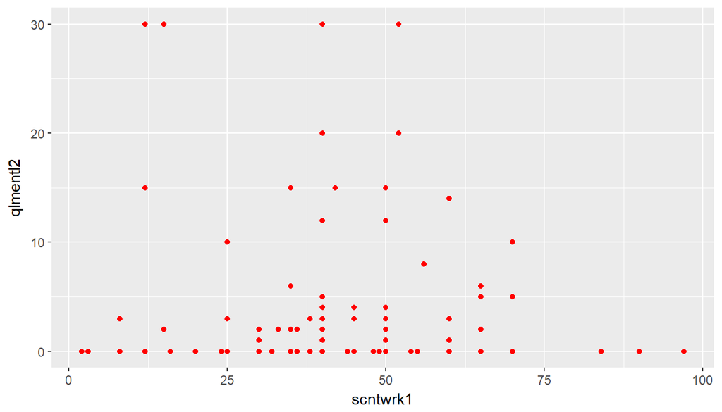

```r
          #mutate(diffgender=as.numeric(menthlth) + as.numeric(physhlth))
ggplot(data = brfss2013, mapping = aes(x=scntwrk1,y = qlmentl2))+  geom_point(colour="red")
```

This scatter plot shows relation between scntwrk1 - How Many Hours Per Week Do You Work? and qlmentl2 - How Many Days Depressed In Past 30 Days? To our surprise, the maximum of hours when people feel depressed is around 12 hours, and it is not necessarily working less cause more depression

```r
brfss2013 %>%
  filter(!is.na(scntwrk1),!is.na(qlmentl2))  %>%
  summarise(scntwrk1mean = mean(scntwrk1), scntwrk1median = median(scntwrk1), scntwrk1sd = sd(scntwrk1), scntwrk1min = min(scntwrk1), scntwrk1max = max(scntwrk1))
```

```
##   scntwrk1mean scntwrk1median scntwrk1sd scntwrk1min scntwrk1max
## 1     42.36306             40   15.85518           2          97
```

Summary statistics of scntwrk1 showing mean, median, standart deviation, min, max.

**Research quesion 2:**

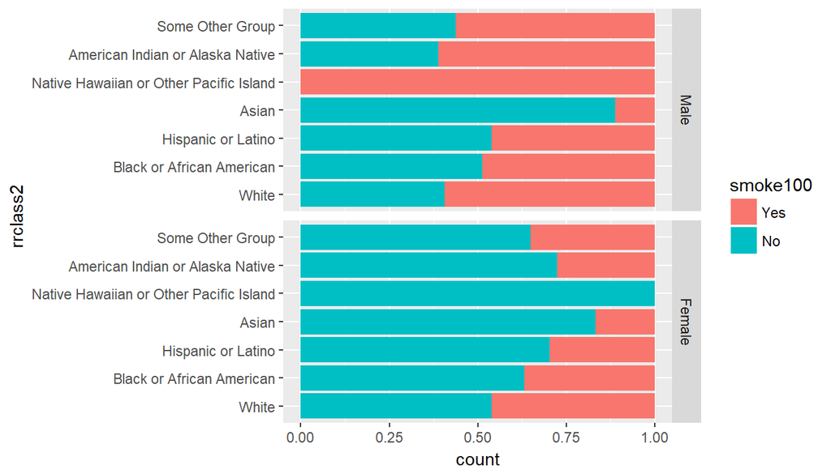

```r
load("brfss2013.RData")
brfss2013 <- brfss2013 %>%
           filter(!is.na(smoke100), !is.na(rrclass2), stateres == "Yes")
#ggplot(data = brfss2013, mapping = aes(rrclass2))+  geom_histogram(stat="count")
ggplot(data = brfss2013, mapping = aes(rrclass2,fill = smoke100))+  geom_bar(position="fill") + coord_flip() +   facet_grid(sex ~.)
```

```r
load("brfss2013.RData")
brfss2013 %>%
  group_by(smoke100,stateres,rrclass2) %>%
  summarise(count = n())  %>%
  filter(!is.na(smoke100), !is.na(rrclass2), stateres == "Yes")
```

```
## # A tibble: 14 x 4
## # Groups:   smoke100, stateres [2]
##    smoke100 stateres rrclass2                                count
##    <fct>    <fct>    <fct>                                   <int>
##  1 Yes      Yes      White                                    1160
##  2 Yes      Yes      Black or African American                  55
##  3 Yes      Yes      Hispanic or Latino                         67
##  4 Yes      Yes      Asian                                       4
##  5 Yes      Yes      Native Hawaiian or Other Pacific Island     2
##  6 Yes      Yes      American Indian or Alaska Native           22
##  7 Yes      Yes      Some Other Group                           16
##  8 No       Yes      White                                    1121
##  9 No       Yes      Black or African American                  81
## 10 No       Yes      Hispanic or Latino                        124
## 11 No       Yes      Asian                                      23
## 12 No       Yes      Native Hawaiian or Other Pacific Island     1
## 13 No       Yes      American Indian or Alaska Native           36
## 14 No       Yes      Some Other Group                           20
```

Total number of smoke100 and state residences people by races (rrclass2).

**Research quesion 3:**

```r
load("brfss2013.RData")
```

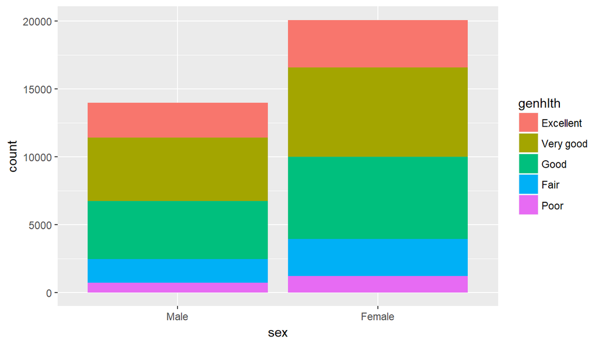

```r
brfss2013 <- brfss2013 %>%
           filter(imonth == "January",!is.na(sex),!is.na(genhlth))
ggplot(data = brfss2013, mapping = aes(sex,fill = genhlth))+  geom_bar(position="stack")
```

Plot shows the gender depndence general health condidion (genlth) of people being interviewed in January. There are 5 possible categories for genhlth: Excellent, Very good, Good, Fair, Poor. The minimum genhlth is poor for both Male a Female (the total number of Male are less than Female). Generally, the people being interview in January possess Very Good or Good health condition.

```r
load("brfss2013.RData")
brfss2013 %>%
  group_by(genhlth,imonth,sex) %>%
  summarise(count = n())  %>%
 filter(!is.na(genhlth),imonth == "January",!is.na(sex))
```

```
## # A tibble: 10 x 4
## # Groups:   genhlth, imonth [5]
##    genhlth   imonth  sex    count
##    <fct>     <fct>   <fct>  <int>
##  1 Excellent January Male    2582
##  2 Excellent January Female  3511
##  3 Very good January Male    4652
##  4 Very good January Female  6565
##  5 Good      January Male    4297
##  6 Good      January Female  6057
##  7 Fair      January Male    1745
##  8 Fair      January Female  2728
##  9 Poor      January Male     703
## 10 Poor      January Female  1220
```

Summary of general health condition (genlth) for people being interviewed in January by genders.